# Practical Machine Learning Peer-Graded Assessment - Weight Lifting Exercise

Aaron Schlafly

1/25/2021

## Background

This document is prepared as the final assignment for the Practical Machine Learning course from Coursera. This work is not an actuarial communication, and it is personal work not related in any way to my employer.

The objective is to design a prediction model to classify the manner in which 20 exercises were performed based on a machine-learning algorithm trained on 19,622 classified exercises.

## Data

The dataset is licensed under the Creative Commons licenses (CC BY-SA) - citation below

Velloso, E.; Bulling, A.; Gellersen, H.; Ugulino, W.; Fuks, H. **Qualitative Activity Recognition of Weight Lifting Exercises.** Proceedings of 4th International Conference in Cooperation with SIGCHI (Augmented Human ’13) . Stuttgart, Germany: ACM SIGCHI, 2013.

Here I read in the training data only. I wait until later to read in the testing data to avoid confusion and to ensure the testing data aren’t used before the best model is chosen based on the training data.

```r
pml_training = read.csv(url("https://d396qusza40orc.cloudfront.net/predmachlearn/pml-training.csv"))
dim(pml_training)
```

```
## [1] 19622   160
```

According to the paper mentioned above, the researchers used four 9 degrees of freedom Razor inertial measurement units (IMU), which provide three-axes acceleration, gyroscope and magnetometer data. The sensors were placed on the users’ glove (`forearm`), armband(`arm`), lumbar belt(`belt`), and dumbbell(`dumbbell`). Data were collected at a short series of timesteps, after which some key metrics were calculated.

The manner is classified into one correct exercise and four common mistakes, as follows:

Class A: exactly according to specification  
Class B: throwing the elbows to the front  
Class C: lifting the dumbbell only halfway  
Class D: lowering the dumbbell only halfway  
Class E: throwing the hips to the front

When the data set is read in, there are 160 variables, broken down as follows:

- 100 variables ($8 \times 3 \times 4 + 4 = 96 + 4$) come from the combinations of the following:

(In addition to the table below, the extra four variables correspond to `var_total_accel_`[*location*] for the four sensor locations)

| Calculations (8) | Euler Angles (3) | Sensor Locations (4) |
| --- | --- | --- |
| `kurtosis` | `roll` | `belt` |
| `skewness` | `pitch` | `arm` |
| `max` | `yaw` | `dumbbell` |
| `min` |  | `forearm` |
| `amplitude` |  |  |
| `var` |  |  |
| `avg` |  |  |
| `stddev` |  |  |

- 16 variables ($(3 + 1) \times 4 = 16$) come from combinations of the following:

| Euler Angles (3+1) | Sensor Locations (4) |
| --- | --- |
| `roll` | `belt` |
| `pitch` | `arm` |
| `yaw` | `dumbbell` |
| `total` | `forearm` |

- 36 variables ($3 \times 4 \times 3 = 36$) come from combinations of the following:

| Sensors (3) | Sensor Locations (4) | Dimensions (3) |
| --- | --- | --- |
| `accel` | `belt` | `x` |
| `gyros` | `arm` | `y` |
| `magnet` | `dumbbell` | `z` |
|  | `forearm` |  |

- That leaves 8 remaining variables as follows:
  - 1: `X` refers to the observation number.
  - 1: `user_name` identifies the participant
  - 3: `raw_timestamp_part_1`, `raw_timestamp_part_2`, and `cvtd_timestamp` are time variables
  - 2: `new_window` and `num_window` are used to distinguish observation windows
  - 1: The final variable is different between the two files:
    - In `pml_training`, the variable `classe` is the classification provided in order to train the data.
    - In `pml_testing`, the variable `problem_id` is the identifier (1-20) for each of the 20 points to be classified

The first set of 100 variables only exists when a stream of observations is summarized. Those variables are not reliably available for predition. Therefore, only the 16 `roll_`, `pitch_`, and `yaw_` variables plus the 36 `accel_`, `gyros_`, `magnet_`, and `total` variables will be used for predicting. Additionally, the eight remaining variables are identifiers which are not relevant for new data which would come in.

```r
sort(nearZeroVar(pml_training, names = TRUE))
```

```
##  [1] "amplitude_pitch_arm"     "amplitude_roll_arm"
##  [3] "amplitude_roll_forearm"  "amplitude_yaw_belt"
##  [5] "amplitude_yaw_dumbbell"  "amplitude_yaw_forearm"
##  [7] "avg_pitch_arm"           "avg_pitch_forearm"
##  [9] "avg_roll_arm"            "avg_roll_forearm"
## [11] "avg_yaw_arm"             "avg_yaw_forearm"
## [13] "kurtosis_picth_arm"      "kurtosis_picth_belt"
## [15] "kurtosis_picth_dumbbell" "kurtosis_picth_forearm"
## [17] "kurtosis_roll_arm"       "kurtosis_roll_belt"
## [19] "kurtosis_roll_dumbbell"  "kurtosis_roll_forearm"
## [21] "kurtosis_yaw_arm"        "kurtosis_yaw_belt"
## [23] "kurtosis_yaw_dumbbell"   "kurtosis_yaw_forearm"
## [25] "max_roll_arm"            "max_roll_forearm"
## [27] "max_yaw_belt"            "max_yaw_dumbbell"
## [29] "max_yaw_forearm"         "min_pitch_arm"
## [31] "min_roll_arm"            "min_roll_forearm"
## [33] "min_yaw_belt"            "min_yaw_dumbbell"
## [35] "min_yaw_forearm"         "new_window"
## [37] "skewness_pitch_arm"      "skewness_pitch_dumbbell"
## [39] "skewness_pitch_forearm"  "skewness_roll_arm"
## [41] "skewness_roll_belt"      "skewness_roll_belt.1"
## [43] "skewness_roll_dumbbell"  "skewness_roll_forearm"
## [45] "skewness_yaw_arm"        "skewness_yaw_belt"
## [47] "skewness_yaw_dumbbell"   "skewness_yaw_forearm"
## [49] "stddev_pitch_arm"        "stddev_pitch_forearm"
## [51] "stddev_roll_arm"         "stddev_roll_forearm"
## [53] "stddev_yaw_arm"          "stddev_yaw_forearm"
## [55] "var_pitch_arm"           "var_pitch_forearm"
## [57] "var_roll_arm"            "var_roll_forearm"
## [59] "var_yaw_arm"             "var_yaw_forearm"
```

Based on this, the study will focus on the 16 + 36 other variables.

```r
pml_grep_pattern = "^roll_|^pitch_|^yaw|^total|^accel|^gyros|^magnet|classe|problem_id"
pml_pred_vars = grep(pml_grep_pattern, names(pml_training), value = TRUE)
pml_pv_count = length(pml_pred_vars)
pml_small_training = pml_training[,grep(pml_grep_pattern, names(pml_training))]
pml_small_training$classe = as.factor(pml_small_training$classe)
sort(names(pml_small_training))
```

```
##  [1] "accel_arm_x"          "accel_arm_y"          "accel_arm_z"
##  [4] "accel_belt_x"         "accel_belt_y"         "accel_belt_z"
##  [7] "accel_dumbbell_x"     "accel_dumbbell_y"     "accel_dumbbell_z"
## [10] "accel_forearm_x"      "accel_forearm_y"      "accel_forearm_z"
## [13] "classe"               "gyros_arm_x"          "gyros_arm_y"
## [16] "gyros_arm_z"          "gyros_belt_x"         "gyros_belt_y"
## [19] "gyros_belt_z"         "gyros_dumbbell_x"     "gyros_dumbbell_y"
## [22] "gyros_dumbbell_z"     "gyros_forearm_x"      "gyros_forearm_y"
## [25] "gyros_forearm_z"      "magnet_arm_x"         "magnet_arm_y"
## [28] "magnet_arm_z"         "magnet_belt_x"        "magnet_belt_y"
## [31] "magnet_belt_z"        "magnet_dumbbell_x"    "magnet_dumbbell_y"
## [34] "magnet_dumbbell_z"    "magnet_forearm_x"     "magnet_forearm_y"
## [37] "magnet_forearm_z"     "pitch_arm"            "pitch_belt"
## [40] "pitch_dumbbell"       "pitch_forearm"        "roll_arm"
## [43] "roll_belt"            "roll_dumbbell"        "roll_forearm"
## [46] "total_accel_arm"      "total_accel_belt"     "total_accel_dumbbell"
## [49] "total_accel_forearm"  "yaw_arm"              "yaw_belt"
## [52] "yaw_dumbbell"         "yaw_forearm"
```

## Data exploration

In order to determine whether there are any obvious candidates for variables to focus on, I looked at the distributions of groups of variables, split by classification.

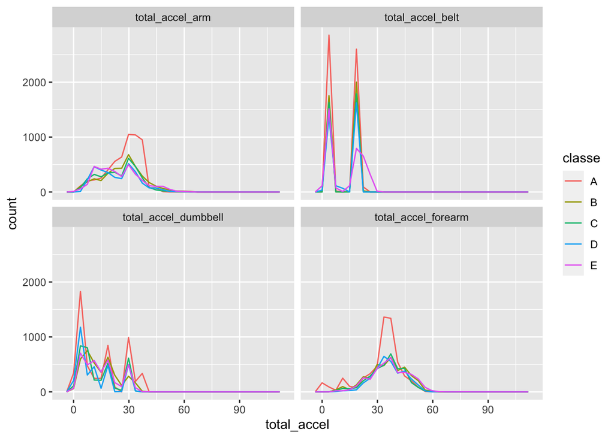

```r
tot_accels = pml_small_training[,c(grep("^total_accel_|classe", names(pml_small_training)))]
tot_accels %>% gather("location","total_accel",1:4) %>%
    ggplot(aes(x = total_accel, col = classe)) +
    geom_freqpoly() + facet_wrap(.~location, ncol = 2)
```

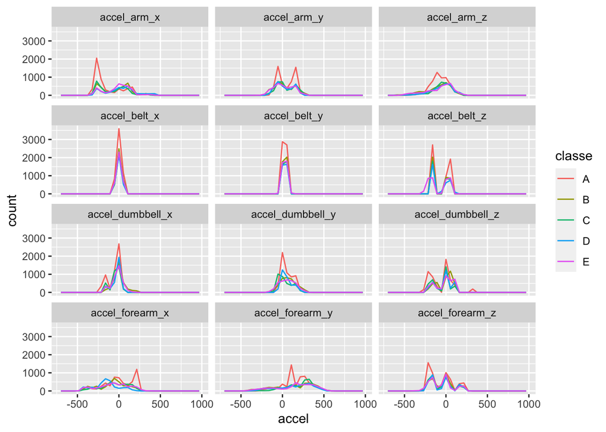

```r
accels = pml_small_training[,c(grep("^accel_|classe", names(pml_small_training)))]
accels %>% gather("location","accel",1:12) %>%
    ggplot(aes(x = accel, col = classe)) +
    geom_freqpoly() + facet_wrap(.~location, ncol = 3)
```

I also looked at the 12 plots for the gyroscope and magenetometer, and the plots showed even less distinction between classes

## Cross Validation

Although the assignment is split into training and testing data, in order to better understand the accuracy and the potential of over-fitting, the training data is split into training data and validation data. The models are then trained on the `pml_train` subset of `"pml_training.csv"` and the `pml_valiation` will be used to better understand the accuracy when applied to a set other than the training set.

```r
set.seed(32343)
inTrain = createDataPartition(y = pml_small_training$classe, p = 0.7, list = FALSE)
pml_train = pml_small_training[inTrain,]
pml_validation = pml_small_training[-inTrain,]
```

## Model Selection

[figure not shown]

```r
pml_pc = prcomp(pml_validation[,-pml_pv_count])
plot(pml_pc$x[,1], pml_pc$x[,2], col = pml_train$classe, cex = 0.2)
```

Based on this, the linear model with principal components model was skipped.

Next I tried to use a tree to allow for more complex classification. Below it can be seen that using `rpart` for a simpler tree produces understandable results, but is a poor predictor for the classification.

```r
system.time({pml_tree_fit = train(classe ~ ., data = pml_train, method = "rpart")})
```

```
##    user  system elapsed
##  21.961   1.975  26.773
```

```r
print(pml_tree_fit$finalModel)
```

```
## n= 13737
##
## node), split, n, loss, yval, (yprob)
##       * denotes terminal node
##
##  1) root 13737 9831 A (0.28 0.19 0.17 0.16 0.18)
##    2) roll_belt< 130.5 12574 8676 A (0.31 0.21 0.19 0.18 0.11)
##      4) pitch_forearm< -34.35 1104    5 A (1 0.0045 0 0 0) *
##      5) pitch_forearm>=-34.35 11470 8671 A (0.24 0.23 0.21 0.2 0.12)
##       10) magnet_dumbbell_y< 439.5 9701 6955 A (0.28 0.18 0.24 0.19 0.11)
##         20) roll_forearm< 124.5 6037 3575 A (0.41 0.18 0.18 0.17 0.058) *
##         21) roll_forearm>=124.5 3664 2464 C (0.078 0.18 0.33 0.23 0.19) *
##       11) magnet_dumbbell_y>=439.5 1769  867 B (0.03 0.51 0.046 0.22 0.19) *
##    3) roll_belt>=130.5 1163    8 E (0.0069 0 0 0 0.99) *
```

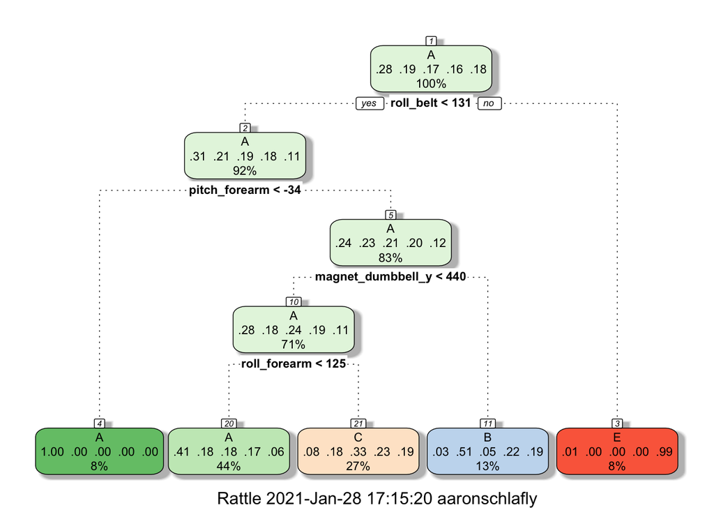

```r
fancyRpartPlot(pml_tree_fit$finalModel)
```

```r
confusionMatrix(pml_train$classe, predict(pml_tree_fit, pml_train))
```

```
## Confusion Matrix and Statistics
##
##           Reference
## Prediction    A    B    C    D    E
##          A 3561   53  284    0    8
##          B 1100  902  656    0    0
##          C 1114   82 1200    0    0
##          D 1018  393  841    0    0
##          E  348  339  683    0 1155
##
## Overall Statistics
##
##                Accuracy : 0.4963
##                  95% CI : (0.4879, 0.5047)
##     No Information Rate : 0.5198
##     P-Value [Acc > NIR] : 1
##
##                   Kappa : 0.3418
##
##  Mcnemar's Test P-Value : NA
##
## Statistics by Class:
##
##                      Class: A Class: B Class: C Class: D Class: E
## Sensitivity            0.4987  0.50989  0.32751       NA  0.99312
## Specificity            0.9477  0.85328  0.88127   0.8361  0.89105
## Pos Pred Value         0.9117  0.33935  0.50083       NA  0.45743
## Neg Pred Value         0.6358  0.92174  0.78274       NA  0.99929
## Prevalence             0.5198  0.12878  0.26672   0.0000  0.08466
## Detection Rate         0.2592  0.06566  0.08736   0.0000  0.08408
## Detection Prevalence   0.2843  0.19349  0.17442   0.1639  0.18381
## Balanced Accuracy      0.7232  0.68158  0.60439       NA  0.94208
```

```r
confusionMatrix(pml_validation$classe, predict(pml_tree_fit, pml_validation))
```

```
## Confusion Matrix and Statistics
##
##           Reference
## Prediction    A    B    C    D    E
##          A 1520   28  120    0    6
##          B  488  384  267    0    0
##          C  479   26  521    0    0
##          D  438  175  351    0    0
##          E  176  147  283    0  476
##
## Overall Statistics
##
##                Accuracy : 0.4929
##                  95% CI : (0.4801, 0.5058)
##     No Information Rate : 0.5269
##     P-Value [Acc > NIR] : 1
##
##                   Kappa : 0.3366
##
##  Mcnemar's Test P-Value : NA
##
## Statistics by Class:
##
##                      Class: A Class: B Class: C Class: D Class: E
## Sensitivity            0.4902  0.50526  0.33787       NA  0.98755
## Specificity            0.9447  0.85268  0.88372   0.8362  0.88784
## Pos Pred Value         0.9080  0.33714  0.50780       NA  0.43993
## Neg Pred Value         0.6246  0.92078  0.78987       NA  0.99875
## Prevalence             0.5269  0.12914  0.26202   0.0000  0.08190
## Detection Rate         0.2583  0.06525  0.08853   0.0000  0.08088
## Detection Prevalence   0.2845  0.19354  0.17434   0.1638  0.18386
## Balanced Accuracy      0.7174  0.67897  0.61080       NA  0.93770
```

The method seems to do a reasonably good job of correctly identifying “E” type problems, but cannot distinguish “D” type at all. All types of exercises are commonly called correct, “A”-type exercises.

For the next attempt, I trained using random forests. The major concern with this is the time it takes. In order to speed things up, I used the `doMC` package to allow multiple cores to be used, reducing the time.

```r
library(doMC)
registerDoMC(cores = 4)

system.time({pml_rf_fit = train(classe ~ ., method = "rf", data = pml_train)})
```

```
##      user    system   elapsed
## 13352.911   193.285 14159.590
```

```r
confusionMatrix(pml_train$classe,predict(pml_rf_fit, pml_train))
```

```
## Confusion Matrix and Statistics
##
##           Reference
## Prediction    A    B    C    D    E
##          A 3906    0    0    0    0
##          B    0 2658    0    0    0
##          C    0    0 2396    0    0
##          D    0    0    0 2252    0
##          E    0    0    0    0 2525
##
## Overall Statistics
##
##                Accuracy : 1
##                  95% CI : (0.9997, 1)
##     No Information Rate : 0.2843
##     P-Value [Acc > NIR] : < 2.2e-16
##
##                   Kappa : 1
##
##  Mcnemar's Test P-Value : NA
##
## Statistics by Class:
##
##                      Class: A Class: B Class: C Class: D Class: E
## Sensitivity            1.0000   1.0000   1.0000   1.0000   1.0000
## Specificity            1.0000   1.0000   1.0000   1.0000   1.0000
## Pos Pred Value         1.0000   1.0000   1.0000   1.0000   1.0000
## Neg Pred Value         1.0000   1.0000   1.0000   1.0000   1.0000
## Prevalence             0.2843   0.1935   0.1744   0.1639   0.1838
## Detection Rate         0.2843   0.1935   0.1744   0.1639   0.1838
## Detection Prevalence   0.2843   0.1935   0.1744   0.1639   0.1838
## Balanced Accuracy      1.0000   1.0000   1.0000   1.0000   1.0000
```

```r
confusionMatrix(pml_validation$classe, predict(pml_rf_fit, pml_validation))
```

```
## Confusion Matrix and Statistics
##
##           Reference
## Prediction    A    B    C    D    E
##          A 1672    0    1    0    1
##          B    6 1133    0    0    0
##          C    0    2 1023    1    0
##          D    1    1    5  956    1
##          E    0    0    0    3 1079
##
## Overall Statistics
##
##                Accuracy : 0.9963
##                  95% CI : (0.9943, 0.9977)
##     No Information Rate : 0.2853
##     P-Value [Acc > NIR] : < 2.2e-16
##
##                   Kappa : 0.9953
##
##  Mcnemar's Test P-Value : NA
##
## Statistics by Class:
##
##                      Class: A Class: B Class: C Class: D Class: E
## Sensitivity            0.9958   0.9974   0.9942   0.9958   0.9981
## Specificity            0.9995   0.9987   0.9994   0.9984   0.9994
## Pos Pred Value         0.9988   0.9947   0.9971   0.9917   0.9972
## Neg Pred Value         0.9983   0.9994   0.9988   0.9992   0.9996
## Prevalence             0.2853   0.1930   0.1749   0.1631   0.1837
## Detection Rate         0.2841   0.1925   0.1738   0.1624   0.1833
## Detection Prevalence   0.2845   0.1935   0.1743   0.1638   0.1839
## Balanced Accuracy      0.9977   0.9980   0.9968   0.9971   0.9988
```

The results work very well, making perfect predictions. When applied to the testing data, the accuracy remains very high, but is, obviously, less than the accuracy for the model applied to the training data.

Finally, a gradient boosing machine method is used.

```r
system.time({pml_gbm_fit = train(classe~., method = "gbm", data = pml_train, verbose = FALSE)})
```

```
##     user   system  elapsed
## 3525.564   47.025 4755.562
```

```r
print(pml_gbm_fit)
```

```
## Stochastic Gradient Boosting
##
## 13737 samples
##    52 predictor
##     5 classes: 'A', 'B', 'C', 'D', 'E'
##
## No pre-processing
## Resampling: Bootstrapped (25 reps)
## Summary of sample sizes: 13737, 13737, 13737, 13737, 13737, 13737, ...
## Resampling results across tuning parameters:
##
##   interaction.depth  n.trees  Accuracy   Kappa
##   1                   50      0.7491284  0.6817892
##   1                  100      0.8172664  0.7686844
##   1                  150      0.8503500  0.8105605
##   2                   50      0.8510490  0.8112380
##   2                  100      0.9014446  0.8752409
##   2                  150      0.9252685  0.9054107
##   3                   50      0.8932835  0.8648411
##   3                  100      0.9365098  0.9196345
##   3                  150      0.9559184  0.9442131
##
## Tuning parameter 'shrinkage' was held constant at a value of 0.1
##
## Tuning parameter 'n.minobsinnode' was held constant at a value of 10
## Accuracy was used to select the optimal model using the largest value.
## The final values used for the model were n.trees = 150, interaction.depth =
##  3, shrinkage = 0.1 and n.minobsinnode = 10.
```

```r
confusionMatrix(pml_train$classe,predict(pml_gbm_fit, pml_train))
```

```
## Confusion Matrix and Statistics
##
##           Reference
## Prediction    A    B    C    D    E
##          A 3874   20    8    4    0
##          B   58 2544   53    2    1
##          C    0   41 2331   21    3
##          D    3   10   50 2176   13
##          E    2   20   13   20 2470
##
## Overall Statistics
##
##                Accuracy : 0.9751
##                  95% CI : (0.9724, 0.9776)
##     No Information Rate : 0.2866
##     P-Value [Acc > NIR] : < 2.2e-16
##
##                   Kappa : 0.9685
##
##  Mcnemar's Test P-Value : 1.598e-11
##
## Statistics by Class:
##
##                      Class: A Class: B Class: C Class: D Class: E
## Sensitivity            0.9840   0.9655   0.9495   0.9789   0.9932
## Specificity            0.9967   0.9897   0.9942   0.9934   0.9951
## Pos Pred Value         0.9918   0.9571   0.9729   0.9663   0.9782
## Neg Pred Value         0.9936   0.9918   0.9891   0.9959   0.9985
## Prevalence             0.2866   0.1918   0.1787   0.1618   0.1810
## Detection Rate         0.2820   0.1852   0.1697   0.1584   0.1798
## Detection Prevalence   0.2843   0.1935   0.1744   0.1639   0.1838
## Balanced Accuracy      0.9904   0.9776   0.9719   0.9861   0.9941
```

```r
confusionMatrix(pml_validation$classe,predict(pml_gbm_fit, pml_validation))
```

```
## Confusion Matrix and Statistics
##
##           Reference
## Prediction    A    B    C    D    E
##          A 1649   15    8    1    1
##          B   41 1061   25    6    6
##          C    0   21  993    9    3
##          D    0    6   27  925    6
##          E    3   11    5   14 1049
##
## Overall Statistics
##
##                Accuracy : 0.9647
##                  95% CI : (0.9596, 0.9692)
##     No Information Rate : 0.2877
##     P-Value [Acc > NIR] : < 2.2e-16
##
##                   Kappa : 0.9553
##
##  Mcnemar's Test P-Value : 6.662e-05
##
## Statistics by Class:
##
##                      Class: A Class: B Class: C Class: D Class: E
## Sensitivity            0.9740   0.9524   0.9386   0.9686   0.9850
## Specificity            0.9940   0.9837   0.9932   0.9921   0.9932
## Pos Pred Value         0.9851   0.9315   0.9678   0.9595   0.9695
## Neg Pred Value         0.9896   0.9888   0.9866   0.9939   0.9967
## Prevalence             0.2877   0.1893   0.1798   0.1623   0.1810
## Detection Rate         0.2802   0.1803   0.1687   0.1572   0.1782
## Detection Prevalence   0.2845   0.1935   0.1743   0.1638   0.1839
## Balanced Accuracy      0.9840   0.9680   0.9659   0.9803   0.9891
```

The model runs more quickly than it did in the case of the random forest, but the accuracy is slightly less, both for the training data as well as for the testing data.

The best prediction model seems to be the random forest version, so this will be the version that I use to make predictions on the data in the file `"pml_testing.csv"`.

```r
pml_testing = read.csv(url("https://d396qusza40orc.cloudfront.net/predmachlearn/pml-testing.csv"))
dim(pml_testing)
```

```
## [1]  20 160
```

My official prediction for the classification is based on the random forest model, as follows:

```r
(test_predict_rf = predict(pml_rf_fit, pml_testing))
```

```
##  [1] B A B A A E D B A A B C B A E E A B B B
## Levels: A B C D E
```

To check the consistency with the prediction from other models, I also produced the predictions using the tree and the gradient boosting machine:

```r
rbind(rf = predict(pml_rf_fit, pml_testing),
      gbm = predict(pml_gbm_fit, pml_testing),
      tree = predict(pml_tree_fit, pml_testing))
```

```
##      [,1] [,2] [,3] [,4] [,5] [,6] [,7] [,8] [,9] [,10] [,11] [,12] [,13] [,14]
## rf      2    1    2    1    1    5    4    2    1     1     2     3     2     1
## gbm     2    1    2    1    1    5    4    2    1     1     2     3     2     1
## tree    3    1    3    1    1    3    3    1    1     1     3     3     3     1
##      [,15] [,16] [,17] [,18] [,19] [,20]
## rf       5     5     1     2     2     2
## gbm      5     5     1     2     2     2
## tree     3     1     1     1     1     3
```

The GBM, which also had a high degree of accuracy, produces identical predictions, which is reassuring, but the tree, which performed poorly, gives different prections, as expected.